# Risk Factor Analysis

## Outcome Variable

**Outcome Variable:** ever_stunted

## Predictor Variables

**Intervention Variable:** gagebrth

**Adjustment Set:**

- arm
- sex
- W_mage
- meducyrs
- feducyrs
- hhwealth_quart
- W_mhtcm
- single
- brthmon
- W_parity
- delta_W_mage
- delta_meducyrs
- delta_feducyrs
- delta_hhwealth_quart
- delta_W_mhtcm
- delta_single
- delta_brthmon
- delta_W_parity

## Stratifying Variables

The analysis was stratified on these variable(s):

- agecat
- studyid
- country

## Data Summary

| agecat | studyid | country | gagebrth | ever_stunted | n_cell | n |
| --- | --- | --- | --- | --- | --- | --- |
| 0-6 months | ki1000108-CMC-V-BCS-2002 | INDIA | [273-287) | 0 | 123 | 346 |
| 0-6 months | ki1000108-CMC-V-BCS-2002 | INDIA | [273-287) | 1 | 23 | 346 |
| 0-6 months | ki1000108-CMC-V-BCS-2002 | INDIA | <259 | 0 | 30 | 346 |
| 0-6 months | ki1000108-CMC-V-BCS-2002 | INDIA | <259 | 1 | 17 | 346 |
| 0-6 months | ki1000108-CMC-V-BCS-2002 | INDIA | [259-273) | 0 | 56 | 346 |
| 0-6 months | ki1000108-CMC-V-BCS-2002 | INDIA | [259-273) | 1 | 18 | 346 |
| 0-6 months | ki1000108-CMC-V-BCS-2002 | INDIA | >=287 | 0 | 65 | 346 |
| 0-6 months | ki1000108-CMC-V-BCS-2002 | INDIA | >=287 | 1 | 14 | 346 |
| 0-6 months | ki1000108-IRC | INDIA | [273-287) | 0 | 149 | 390 |
| 0-6 months | ki1000108-IRC | INDIA | [273-287) | 1 | 16 | 390 |
| 0-6 months | ki1000108-IRC | INDIA | <259 | 0 | 30 | 390 |
| 0-6 months | ki1000108-IRC | INDIA | <259 | 1 | 10 | 390 |
| 0-6 months | ki1000108-IRC | INDIA | [259-273) | 0 | 83 | 390 |
| 0-6 months | ki1000108-IRC | INDIA | [259-273) | 1 | 9 | 390 |
| 0-6 months | ki1000108-IRC | INDIA | >=287 | 0 | 79 | 390 |
| 0-6 months | ki1000108-IRC | INDIA | >=287 | 1 | 14 | 390 |
| 0-6 months | ki1000109-EE | PAKISTAN | [273-287) | 0 | 17 | 379 |
| 0-6 months | ki1000109-EE | PAKISTAN | [273-287) | 1 | 7 | 379 |
| 0-6 months | ki1000109-EE | PAKISTAN | <259 | 0 | 160 | 379 |
| 0-6 months | ki1000109-EE | PAKISTAN | <259 | 1 | 85 | 379 |
| 0-6 months | ki1000109-EE | PAKISTAN | [259-273) | 0 | 71 | 379 |
| 0-6 months | ki1000109-EE | PAKISTAN | [259-273) | 1 | 38 | 379 |
| 0-6 months | ki1000109-EE | PAKISTAN | >=287 | 0 | 1 | 379 |
| 0-6 months | ki1000109-EE | PAKISTAN | >=287 | 1 | 0 | 379 |
| 0-6 months | ki1000304b-SAS-CompFeed | INDIA | [273-287) | 0 | 37 | 1512 |
| 0-6 months | ki1000304b-SAS-CompFeed | INDIA | [273-287) | 1 | 5 | 1512 |
| 0-6 months | ki1000304b-SAS-CompFeed | INDIA | <259 | 0 | 834 | 1512 |
| 0-6 months | ki1000304b-SAS-CompFeed | INDIA | <259 | 1 | 376 | 1512 |
| 0-6 months | ki1000304b-SAS-CompFeed | INDIA | [259-273) | 0 | 206 | 1512 |
| 0-6 months | ki1000304b-SAS-CompFeed | INDIA | [259-273) | 1 | 51 | 1512 |

[output cut: 270 more lines]

The following strata were considered:

- agecat: 0-24 months, studyid: ki1000108-CMC-V-BCS-2002, country: INDIA
- agecat: 0-24 months, studyid: ki1000108-IRC, country: INDIA
- agecat: 0-24 months, studyid: ki1000109-EE, country: PAKISTAN
- agecat: 0-24 months, studyid: ki1000304b-SAS-CompFeed, country: INDIA
- agecat: 0-24 months, studyid: ki1017093c-NIH-Crypto, country: BANGLADESH
- agecat: 0-24 months, studyid: ki1066203-TanzaniaChild2, country: TANZANIA, UNITED REPUBLIC OF
- agecat: 0-24 months, studyid: ki1101329-Keneba, country: GAMBIA
- agecat: 0-24 months, studyid: ki1113344-GMS-Nepal, country: NEPAL
- agecat: 0-24 months, studyid: ki1119695-PROBIT, country: BELARUS
- agecat: 0-24 months, studyid: ki1135781-COHORTS, country: GUATEMALA
- agecat: 0-24 months, studyid: ki1135781-COHORTS, country: INDIA
- agecat: 0-24 months, studyid: ki1135781-COHORTS, country: PHILIPPINES
- agecat: 0-24 months, studyid: kiGH5241-JiVitA-3, country: BANGLADESH
- agecat: 0-6 months, studyid: ki1000108-CMC-V-BCS-2002, country: INDIA
- agecat: 0-6 months, studyid: ki1000108-IRC, country: INDIA
- agecat: 0-6 months, studyid: ki1000109-EE, country: PAKISTAN
- agecat: 0-6 months, studyid: ki1000304b-SAS-CompFeed, country: INDIA
- agecat: 0-6 months, studyid: ki1017093c-NIH-Crypto, country: BANGLADESH
- agecat: 0-6 months, studyid: ki1066203-TanzaniaChild2, country: TANZANIA, UNITED REPUBLIC OF
- agecat: 0-6 months, studyid: ki1101329-Keneba, country: GAMBIA
- agecat: 0-6 months, studyid: ki1113344-GMS-Nepal, country: NEPAL
- agecat: 0-6 months, studyid: ki1119695-PROBIT, country: BELARUS
- agecat: 0-6 months, studyid: ki1135781-COHORTS, country: GUATEMALA
- agecat: 0-6 months, studyid: ki1135781-COHORTS, country: INDIA
- agecat: 0-6 months, studyid: ki1135781-COHORTS, country: PHILIPPINES
- agecat: 0-6 months, studyid: kiGH5241-JiVitA-3, country: BANGLADESH
- agecat: 6-24 months, studyid: ki1000108-CMC-V-BCS-2002, country: INDIA
- agecat: 6-24 months, studyid: ki1000108-IRC, country: INDIA
- agecat: 6-24 months, studyid: ki1000109-EE, country: PAKISTAN
- agecat: 6-24 months, studyid: ki1000304b-SAS-CompFeed, country: INDIA
- agecat: 6-24 months, studyid: ki1017093c-NIH-Crypto, country: BANGLADESH
- agecat: 6-24 months, studyid: ki1066203-TanzaniaChild2, country: TANZANIA, UNITED REPUBLIC OF
- agecat: 6-24 months, studyid: ki1101329-Keneba, country: GAMBIA
- agecat: 6-24 months, studyid: ki1113344-GMS-Nepal, country: NEPAL
- agecat: 6-24 months, studyid: ki1119695-PROBIT, country: BELARUS
- agecat: 6-24 months, studyid: ki1135781-COHORTS, country: GUATEMALA
- agecat: 6-24 months, studyid: ki1135781-COHORTS, country: INDIA
- agecat: 6-24 months, studyid: ki1135781-COHORTS, country: PHILIPPINES
- agecat: 6-24 months, studyid: kiGH5241-JiVitA-3, country: BANGLADESH

## Methods Detail

We’re interested in the causal parameters $E[Y_a]$ for all values of $a \in \mathcal{A}$. These parameters represent the mean outcome if, possibly contrary to fact, we intervened to set all units to have $A=a$. Under the randomization and positivity assumptions, these are identified by the statistical parameters $\psi_a=E_W[E_{Y|A,W}(Y|A=a,W)]$. In addition, we’re interested in the mean of $Y$, $E[Y]$ under no intervention (the observed mean). We will estimate these parameters by using SuperLearner to fit the relevant likelihood factors – $E_{Y|A,W}(Y|A=a,W)$ and $p(A=a|W)$, and then updating our likelihood fit using a joint TMLE.

For unadjusted analyses ($W=\{\}$), initial likelihoods were estimated using Lrnr_glm to estimate the simple $E(Y|A)$ and Lrnr_mean to estimate $p(A)$. For adjusted analyses, a small library containing Lrnr_glmnet, Lrnr_xgboost, and Lrnr_mean was used.

Having estimated these parameters, we will then use the delta method to estimate relative risks and attributable risks relative to a prespecified baseline level of $A$.

[output not shown]

```
##            ever_stunted
## gagebrth      0
##   [273-287) 451
##   <259      145
##   [259-273) 250
##   >=287     256
```

# Results Detail

## Results Plots

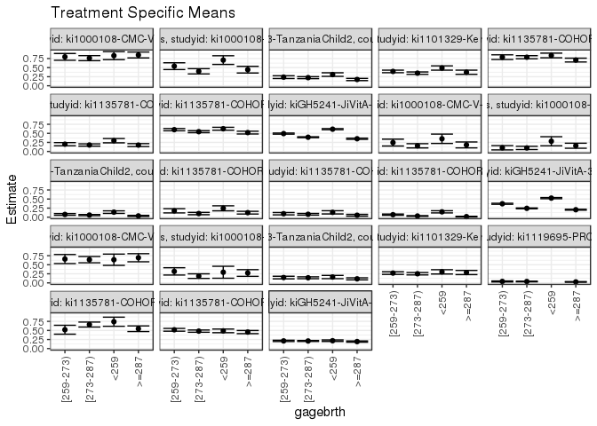

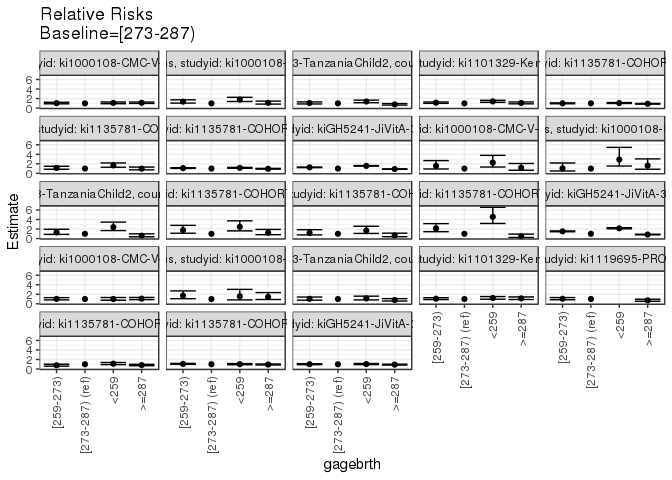

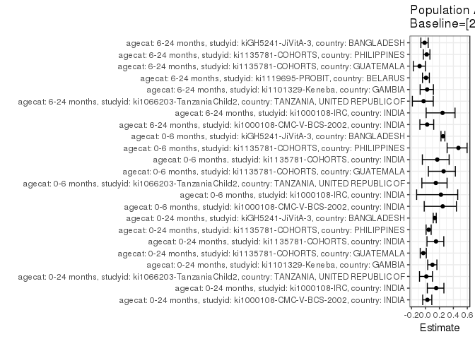

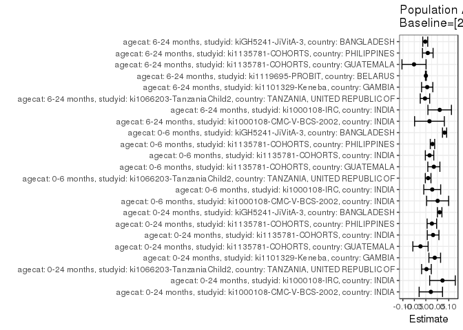

## Results Table

### Parameter: TSM

| agecat | studyid | country | intervention_level | baseline_level | estimate | ci_lower | ci_upper |
| --- | --- | --- | --- | --- | --- | --- | --- |
| 0-24 months | ki1000108-CMC-V-BCS-2002 | INDIA | [273-287) | NA | 0.7616028 | 0.6926678 | 0.8305378 |
| 0-24 months | ki1000108-CMC-V-BCS-2002 | INDIA | <259 | NA | 0.8302809 | 0.7202965 | 0.9402653 |
| 0-24 months | ki1000108-CMC-V-BCS-2002 | INDIA | [259-273) | NA | 0.7965806 | 0.7033468 | 0.8898143 |
| 0-24 months | ki1000108-CMC-V-BCS-2002 | INDIA | >=287 | NA | 0.8487887 | 0.7675837 | 0.9299937 |
| 0-24 months | ki1000108-IRC | INDIA | [273-287) | NA | 0.3991988 | 0.3267171 | 0.4716805 |
| 0-24 months | ki1000108-IRC | INDIA | <259 | NA | 0.7075308 | 0.5882144 | 0.8268472 |
| 0-24 months | ki1000108-IRC | INDIA | [259-273) | NA | 0.5403902 | 0.4468963 | 0.6338841 |
| 0-24 months | ki1000108-IRC | INDIA | >=287 | NA | 0.4440359 | 0.3519627 | 0.5361090 |
| 0-24 months | ki1066203-TanzaniaChild2 | TANZANIA, UNITED REPUBLIC OF | [273-287) | NA | 0.2239707 | 0.1968124 | 0.2511290 |
| 0-24 months | ki1066203-TanzaniaChild2 | TANZANIA, UNITED REPUBLIC OF | <259 | NA | 0.3090537 | 0.2599067 | 0.3582007 |
| 0-24 months | ki1066203-TanzaniaChild2 | TANZANIA, UNITED REPUBLIC OF | [259-273) | NA | 0.2380497 | 0.2001481 | 0.2759514 |
| 0-24 months | ki1066203-TanzaniaChild2 | TANZANIA, UNITED REPUBLIC OF | >=287 | NA | 0.1734037 | 0.1431419 | 0.2036655 |
| 0-24 months | ki1101329-Keneba | GAMBIA | [273-287) | NA | 0.3478551 | 0.3145332 | 0.3811770 |
| 0-24 months | ki1101329-Keneba | GAMBIA | <259 | NA | 0.4899431 | 0.4312088 | 0.5486773 |
| 0-24 months | ki1101329-Keneba | GAMBIA | [259-273) | NA | 0.3954379 | 0.3605686 | 0.4303071 |
| 0-24 months | ki1101329-Keneba | GAMBIA | >=287 | NA | 0.3734930 | 0.3161187 | 0.4308672 |
| 0-24 months | ki1135781-COHORTS | GUATEMALA | [273-287) | NA | 0.7867573 | 0.7439484 | 0.8295661 |
| 0-24 months | ki1135781-COHORTS | GUATEMALA | <259 | NA | 0.8353673 | 0.7711583 | 0.8995763 |
| 0-24 months | ki1135781-COHORTS | GUATEMALA | [259-273) | NA | 0.7886148 | 0.7242565 | 0.8529730 |
| 0-24 months | ki1135781-COHORTS | GUATEMALA | >=287 | NA | 0.7087292 | 0.6562842 | 0.7611743 |
| 0-24 months | ki1135781-COHORTS | INDIA | [273-287) | NA | 0.1783813 | 0.1467594 | 0.2100033 |
| 0-24 months | ki1135781-COHORTS | INDIA | <259 | NA | 0.2974013 | 0.2381277 | 0.3566750 |
| 0-24 months | ki1135781-COHORTS | INDIA | [259-273) | NA | 0.2008834 | 0.1576443 | 0.2441225 |
| 0-24 months | ki1135781-COHORTS | INDIA | >=287 | NA | 0.1759052 | 0.1352316 | 0.2165788 |
| 0-24 months | ki1135781-COHORTS | PHILIPPINES | [273-287) | NA | 0.5458267 | 0.5187365 | 0.5729169 |
| 0-24 months | ki1135781-COHORTS | PHILIPPINES | <259 | NA | 0.6262510 | 0.5863392 | 0.6661627 |
| 0-24 months | ki1135781-COHORTS | PHILIPPINES | [259-273) | NA | 0.6011745 | 0.5701093 | 0.6322396 |
| 0-24 months | ki1135781-COHORTS | PHILIPPINES | >=287 | NA | 0.5207641 | 0.4826546 | 0.5588735 |
| 0-24 months | kiGH5241-JiVitA-3 | BANGLADESH | [273-287) | NA | 0.3924700 | 0.3800446 | 0.4048954 |
| 0-24 months | kiGH5241-JiVitA-3 | BANGLADESH | <259 | NA | 0.6148494 | 0.5993409 | 0.6303579 |

[output cut: 61 more lines]

### Parameter: E(Y)

| agecat | studyid | country | intervention_level | baseline_level | estimate | ci_lower | ci_upper |
| --- | --- | --- | --- | --- | --- | --- | --- |
| 0-24 months | ki1000108-CMC-V-BCS-2002 | INDIA | NA | NA | 0.7834758 | 0.7403259 | 0.8266257 |
| 0-24 months | ki1000108-IRC | INDIA | NA | NA | 0.4717949 | 0.4221869 | 0.5214028 |
| 0-24 months | ki1066203-TanzaniaChild2 | TANZANIA, UNITED REPUBLIC OF | NA | NA | 0.2267081 | 0.2094190 | 0.2439972 |
| 0-24 months | ki1101329-Keneba | GAMBIA | NA | NA | 0.3867371 | 0.3636073 | 0.4098669 |
| 0-24 months | ki1135781-COHORTS | GUATEMALA | NA | NA | 0.7634804 | 0.7343060 | 0.7926548 |
| 0-24 months | ki1135781-COHORTS | INDIA | NA | NA | 0.2100656 | 0.1884951 | 0.2316362 |
| 0-24 months | ki1135781-COHORTS | PHILIPPINES | NA | NA | 0.5722296 | 0.5546161 | 0.5898431 |
| 0-24 months | kiGH5241-JiVitA-3 | BANGLADESH | NA | NA | 0.4527871 | 0.4444343 | 0.4611400 |
| 0-6 months | ki1000108-CMC-V-BCS-2002 | INDIA | NA | NA | 0.2080925 | 0.1652570 | 0.2509280 |
| 0-6 months | ki1000108-IRC | INDIA | NA | NA | 0.1256410 | 0.0927040 | 0.1585780 |
| 0-6 months | ki1066203-TanzaniaChild2 | TANZANIA, UNITED REPUBLIC OF | NA | NA | 0.0678793 | 0.0574928 | 0.0782659 |
| 0-6 months | ki1135781-COHORTS | GUATEMALA | NA | NA | 0.1345408 | 0.1104700 | 0.1586115 |
| 0-6 months | ki1135781-COHORTS | INDIA | NA | NA | 0.0961538 | 0.0804339 | 0.1118738 |
| 0-6 months | ki1135781-COHORTS | PHILIPPINES | NA | NA | 0.0613456 | 0.0528029 | 0.0698884 |
| 0-6 months | kiGH5241-JiVitA-3 | BANGLADESH | NA | NA | 0.3255272 | 0.3180302 | 0.3330241 |
| 6-24 months | ki1000108-CMC-V-BCS-2002 | INDIA | NA | NA | 0.6556777 | 0.5992111 | 0.7121442 |
| 6-24 months | ki1000108-IRC | INDIA | NA | NA | 0.2469136 | 0.1998872 | 0.2939400 |
| 6-24 months | ki1066203-TanzaniaChild2 | TANZANIA, UNITED REPUBLIC OF | NA | NA | 0.1375936 | 0.1213893 | 0.1537978 |
| 6-24 months | ki1101329-Keneba | GAMBIA | NA | NA | 0.2578837 | 0.2351779 | 0.2805894 |
| 6-24 months | ki1119695-PROBIT | BELARUS | NA | NA | 0.0380298 | 0.0285924 | 0.0474672 |
| 6-24 months | ki1135781-COHORTS | GUATEMALA | NA | NA | 0.6107226 | 0.5645294 | 0.6569158 |
| 6-24 months | ki1135781-COHORTS | PHILIPPINES | NA | NA | 0.4900272 | 0.4691618 | 0.5108926 |
| 6-24 months | kiGH5241-JiVitA-3 | BANGLADESH | NA | NA | 0.2071640 | 0.1978526 | 0.2164754 |

### Parameter: RR

| agecat | studyid | country | intervention_level | baseline_level | estimate | ci_lower | ci_upper |
| --- | --- | --- | --- | --- | --- | --- | --- |
| 0-24 months | ki1000108-CMC-V-BCS-2002 | INDIA | [273-287) | [273-287) | 1.0000000 | 1.0000000 | 1.0000000 |
| 0-24 months | ki1000108-CMC-V-BCS-2002 | INDIA | <259 | [273-287) | 1.0901758 | 0.9287603 | 1.2796447 |
| 0-24 months | ki1000108-CMC-V-BCS-2002 | INDIA | [259-273) | [273-287) | 1.0459266 | 0.9022265 | 1.2125141 |
| 0-24 months | ki1000108-CMC-V-BCS-2002 | INDIA | >=287 | [273-287) | 1.1144769 | 0.9769512 | 1.2713621 |
| 0-24 months | ki1000108-IRC | INDIA | [273-287) | [273-287) | 1.0000000 | 1.0000000 | 1.0000000 |
| 0-24 months | ki1000108-IRC | INDIA | <259 | [273-287) | 1.7723770 | 1.3848465 | 2.2683525 |
| 0-24 months | ki1000108-IRC | INDIA | [259-273) | [273-287) | 1.3536869 | 1.0538682 | 1.7388021 |
| 0-24 months | ki1000108-IRC | INDIA | >=287 | [273-287) | 1.1123176 | 0.8446520 | 1.4648051 |
| 0-24 months | ki1066203-TanzaniaChild2 | TANZANIA, UNITED REPUBLIC OF | [273-287) | [273-287) | 1.0000000 | 1.0000000 | 1.0000000 |
| 0-24 months | ki1066203-TanzaniaChild2 | TANZANIA, UNITED REPUBLIC OF | <259 | [273-287) | 1.3798846 | 1.1310428 | 1.6834742 |
| 0-24 months | ki1066203-TanzaniaChild2 | TANZANIA, UNITED REPUBLIC OF | [259-273) | [273-287) | 1.0628611 | 0.8711218 | 1.2968034 |
| 0-24 months | ki1066203-TanzaniaChild2 | TANZANIA, UNITED REPUBLIC OF | >=287 | [273-287) | 0.7742249 | 0.6269178 | 0.9561447 |
| 0-24 months | ki1101329-Keneba | GAMBIA | [273-287) | [273-287) | 1.0000000 | 1.0000000 | 1.0000000 |
| 0-24 months | ki1101329-Keneba | GAMBIA | <259 | [273-287) | 1.4084689 | 1.2108507 | 1.6383396 |
| 0-24 months | ki1101329-Keneba | GAMBIA | [259-273) | [273-287) | 1.1367891 | 1.0021143 | 1.2895629 |
| 0-24 months | ki1101329-Keneba | GAMBIA | >=287 | [273-287) | 1.0737028 | 0.8987345 | 1.2827344 |
| 0-24 months | ki1135781-COHORTS | GUATEMALA | [273-287) | [273-287) | 1.0000000 | 1.0000000 | 1.0000000 |
| 0-24 months | ki1135781-COHORTS | GUATEMALA | <259 | [273-287) | 1.0617853 | 0.9675529 | 1.1651951 |
| 0-24 months | ki1135781-COHORTS | GUATEMALA | [259-273) | [273-287) | 1.0023609 | 0.9097159 | 1.1044409 |
| 0-24 months | ki1135781-COHORTS | GUATEMALA | >=287 | [273-287) | 0.9008233 | 0.8227556 | 0.9862984 |
| 0-24 months | ki1135781-COHORTS | INDIA | [273-287) | [273-287) | 1.0000000 | 1.0000000 | 1.0000000 |
| 0-24 months | ki1135781-COHORTS | INDIA | <259 | [273-287) | 1.6672223 | 1.2789805 | 2.1733170 |
| 0-24 months | ki1135781-COHORTS | INDIA | [259-273) | [273-287) | 1.1261457 | 0.8545740 | 1.4840192 |
| 0-24 months | ki1135781-COHORTS | INDIA | >=287 | [273-287) | 0.9861187 | 0.7386425 | 1.3165097 |
| 0-24 months | ki1135781-COHORTS | PHILIPPINES | [273-287) | [273-287) | 1.0000000 | 1.0000000 | 1.0000000 |
| 0-24 months | ki1135781-COHORTS | PHILIPPINES | <259 | [273-287) | 1.1473440 | 1.0593748 | 1.2426180 |
| 0-24 months | ki1135781-COHORTS | PHILIPPINES | [259-273) | [273-287) | 1.1014017 | 1.0264863 | 1.1817846 |
| 0-24 months | ki1135781-COHORTS | PHILIPPINES | >=287 | [273-287) | 0.9540832 | 0.8742439 | 1.0412136 |
| 0-24 months | kiGH5241-JiVitA-3 | BANGLADESH | [273-287) | [273-287) | 1.0000000 | 1.0000000 | 1.0000000 |
| 0-24 months | kiGH5241-JiVitA-3 | BANGLADESH | <259 | [273-287) | 1.5666151 | 1.5046229 | 1.6311614 |

[output cut: 61 more lines]

### Parameter: PAR

| agecat | studyid | country | intervention_level | baseline_level | estimate | ci_lower | ci_upper |
| --- | --- | --- | --- | --- | --- | --- | --- |
| 0-24 months | ki1000108-CMC-V-BCS-2002 | INDIA | [273-287) | NA | 0.0218730 | -0.0290799 | 0.0728259 |
| 0-24 months | ki1000108-IRC | INDIA | [273-287) | NA | 0.0725961 | 0.0168006 | 0.1283916 |
| 0-24 months | ki1066203-TanzaniaChild2 | TANZANIA, UNITED REPUBLIC OF | [273-287) | NA | 0.0027374 | -0.0182845 | 0.0237592 |
| 0-24 months | ki1101329-Keneba | GAMBIA | [273-287) | NA | 0.0388820 | 0.0134311 | 0.0643330 |
| 0-24 months | ki1135781-COHORTS | GUATEMALA | [273-287) | NA | -0.0232769 | -0.0565132 | 0.0099594 |
| 0-24 months | ki1135781-COHORTS | INDIA | [273-287) | NA | 0.0316843 | 0.0063511 | 0.0570175 |
| 0-24 months | ki1135781-COHORTS | PHILIPPINES | [273-287) | NA | 0.0264028 | 0.0057031 | 0.0471026 |
| 0-24 months | kiGH5241-JiVitA-3 | BANGLADESH | [273-287) | NA | 0.0603172 | 0.0505420 | 0.0700924 |
| 0-6 months | ki1000108-CMC-V-BCS-2002 | INDIA | [273-287) | NA | 0.0514866 | 0.0035096 | 0.0994636 |
| 0-6 months | ki1000108-IRC | INDIA | [273-287) | NA | 0.0278971 | -0.0089021 | 0.0646963 |
| 0-6 months | ki1066203-TanzaniaChild2 | TANZANIA, UNITED REPUBLIC OF | [273-287) | NA | 0.0100557 | -0.0022116 | 0.0223230 |
| 0-6 months | ki1135781-COHORTS | GUATEMALA | [273-287) | NA | 0.0349701 | 0.0086515 | 0.0612888 |
| 0-6 months | ki1135781-COHORTS | INDIA | [273-287) | NA | 0.0162765 | -0.0021209 | 0.0346738 |
| 0-6 months | ki1135781-COHORTS | PHILIPPINES | [273-287) | NA | 0.0290054 | 0.0194632 | 0.0385475 |
| 0-6 months | kiGH5241-JiVitA-3 | BANGLADESH | [273-287) | NA | 0.0816743 | 0.0725572 | 0.0907914 |
| 6-24 months | ki1000108-CMC-V-BCS-2002 | INDIA | [273-287) | NA | 0.0158934 | -0.0489093 | 0.0806960 |
| 6-24 months | ki1000108-IRC | INDIA | [273-287) | NA | 0.0604284 | 0.0091977 | 0.1116591 |
| 6-24 months | ki1066203-TanzaniaChild2 | TANZANIA, UNITED REPUBLIC OF | [273-287) | NA | -0.0036960 | -0.0242416 | 0.0168496 |
| 6-24 months | ki1101329-Keneba | GAMBIA | [273-287) | NA | 0.0060398 | -0.0184793 | 0.0305590 |
| 6-24 months | ki1119695-PROBIT | BELARUS | [273-287) | NA | 0.0003021 | -0.0015888 | 0.0021931 |
| 6-24 months | ki1135781-COHORTS | GUATEMALA | [273-287) | NA | -0.0514384 | -0.1039265 | 0.0010497 |
| 6-24 months | ki1135781-COHORTS | PHILIPPINES | [273-287) | NA | 0.0085671 | -0.0145461 | 0.0316803 |
| 6-24 months | kiGH5241-JiVitA-3 | BANGLADESH | [273-287) | NA | -0.0024918 | -0.0133251 | 0.0083415 |

### Parameter: PAF

| agecat | studyid | country | intervention_level | baseline_level | estimate | ci_lower | ci_upper |
| --- | --- | --- | --- | --- | --- | --- | --- |
| 0-24 months | ki1000108-CMC-V-BCS-2002 | INDIA | [273-287) | NA | 0.0279179 | -0.0394705 | 0.0909375 |
| 0-24 months | ki1000108-IRC | INDIA | [273-287) | NA | 0.1538721 | 0.0267509 | 0.2643894 |
| 0-24 months | ki1066203-TanzaniaChild2 | TANZANIA, UNITED REPUBLIC OF | [273-287) | NA | 0.0120745 | -0.0851437 | 0.1005828 |
| 0-24 months | ki1101329-Keneba | GAMBIA | [273-287) | NA | 0.1005386 | 0.0323642 | 0.1639098 |
| 0-24 months | ki1135781-COHORTS | GUATEMALA | [273-287) | NA | -0.0304879 | -0.0750464 | 0.0122238 |
| 0-24 months | ki1135781-COHORTS | INDIA | [273-287) | NA | 0.1508305 | 0.0218545 | 0.2628000 |
| 0-24 months | ki1135781-COHORTS | PHILIPPINES | [273-287) | NA | 0.0461403 | 0.0092526 | 0.0816546 |
| 0-24 months | kiGH5241-JiVitA-3 | BANGLADESH | [273-287) | NA | 0.1332131 | 0.1113784 | 0.1545113 |
| 0-6 months | ki1000108-CMC-V-BCS-2002 | INDIA | [273-287) | NA | 0.2474219 | -0.0178882 | 0.4435795 |
| 0-6 months | ki1000108-IRC | INDIA | [273-287) | NA | 0.2220381 | -0.1263741 | 0.4626787 |
| 0-6 months | ki1066203-TanzaniaChild2 | TANZANIA, UNITED REPUBLIC OF | [273-287) | NA | 0.1481411 | -0.0515224 | 0.3098924 |
| 0-6 months | ki1135781-COHORTS | GUATEMALA | [273-287) | NA | 0.2599221 | 0.0419441 | 0.4283055 |
| 0-6 months | ki1135781-COHORTS | INDIA | [273-287) | NA | 0.1692753 | -0.0445009 | 0.3392983 |
| 0-6 months | ki1135781-COHORTS | PHILIPPINES | [273-287) | NA | 0.4728185 | 0.3105345 | 0.5969047 |
| 0-6 months | kiGH5241-JiVitA-3 | BANGLADESH | [273-287) | NA | 0.2508985 | 0.2224409 | 0.2783147 |
| 6-24 months | ki1000108-CMC-V-BCS-2002 | INDIA | [273-287) | NA | 0.0242396 | -0.0798247 | 0.1182751 |
| 6-24 months | ki1000108-IRC | INDIA | [273-287) | NA | 0.2447349 | 0.0099003 | 0.4238708 |
| 6-24 months | ki1066203-TanzaniaChild2 | TANZANIA, UNITED REPUBLIC OF | [273-287) | NA | -0.0268618 | -0.1875459 | 0.1120805 |
| 6-24 months | ki1101329-Keneba | GAMBIA | [273-287) | NA | 0.0234208 | -0.0763842 | 0.1139716 |
| 6-24 months | ki1119695-PROBIT | BELARUS | [273-287) | NA | 0.0079443 | -0.0424853 | 0.0559344 |
| 6-24 months | ki1135781-COHORTS | GUATEMALA | [273-287) | NA | -0.0842255 | -0.1742147 | -0.0011328 |
| 6-24 months | ki1135781-COHORTS | PHILIPPINES | [273-287) | NA | 0.0174829 | -0.0308210 | 0.0635233 |
| 6-24 months | kiGH5241-JiVitA-3 | BANGLADESH | [273-287) | NA | -0.0120283 | -0.0657453 | 0.0389811 |